# Anova_HW

Evgeniia Molokova

2022-11-27

# Настройка библиотек

# Загрузка данных и создание исследуемой выборки

```r
soccer_general <- read.csv("C:/Users/Евгения/Downloads/soccer.csv", sep=";")[, 2:6] %>%
  mutate(Position = as.factor(Position),
         Nationality = as.factor(Nationality),
         Age = as.numeric(Age),
         Height = as.numeric(Height)) %>%
  filter(Nationality %in% c("Spanish", "Italian", "German", "English", "Argentinian"))

set.seed(1)

soccer_wrk <- soccer_general[sample(1:nrow(soccer_general), 150), ] %>%
  mutate(Nationality = factor(Nationality))
```

# 1. Дисперсионный анализ ANOVA

```r
oneway.test(Height~Position, data=soccer_wrk)
```

```
##
##  One-way analysis of means (not assuming equal variances)
##
## data:  Height and Position
## F = 15.44, num df = 3.00, denom df = 62.23, p-value = 1.288e-07
```

Интерпретация: мы отвергаем гипотезу об отсуствии связи между позицией игрока и его ростом.

# 2. Post-hoc анализ с использованием процедуры Хоторна-Бретца-Вестфалла

```r
m0 <- lm (Height~Position, data=soccer_wrk)

HBW.comp0 <- m0 %>% glht(linfct = mcp(Position = "Tukey"))

HBW.comp0 %>% summary() #Значения p-value для попарных тестов
```

```
##
##   Simultaneous Tests for General Linear Hypotheses
##
## Multiple Comparisons of Means: Tukey Contrasts
##
##
## Fit: lm(formula = Height ~ Position, data = soccer_wrk)
##
## Linear Hypotheses:
##                              Estimate Std. Error t value Pr(>|t|)
## Forward - Defender == 0        -1.718      1.339  -1.283  0.57138
## Goalkeeper - Defender == 0      5.258      1.513   3.474  0.00366 **
## Midfielder - Defender == 0     -4.218      1.193  -3.535  0.00297 **
## Goalkeeper - Forward == 0       6.976      1.679   4.156  < 0.001 ***
## Midfielder - Forward == 0      -2.500      1.397  -1.790  0.27918
## Midfielder - Goalkeeper == 0   -9.476      1.565  -6.056  < 0.001 ***
## ---
## Signif. codes:  0 '***' 0.001 '**' 0.01 '*' 0.05 '.' 0.1 ' ' 1
## (Adjusted p values reported -- single-step method)
```

```r
HBW.comp0 %>% confint() #Доверительные интервалы для попарных тестов
```

```
##
##   Simultaneous Confidence Intervals
##
## Multiple Comparisons of Means: Tukey Contrasts
##
##
## Fit: lm(formula = Height ~ Position, data = soccer_wrk)
##
## Quantile = 2.5918
## 95% family-wise confidence level
##
##
## Linear Hypotheses:
##                              Estimate lwr      upr
## Forward - Defender == 0       -1.7182  -5.1889   1.7525
## Goalkeeper - Defender == 0     5.2580   1.3355   9.1806
## Midfielder - Defender == 0    -4.2182  -7.3111  -1.1253
## Goalkeeper - Forward == 0      6.9762   2.6254  11.3270
## Midfielder - Forward == 0     -2.5000  -6.1206   1.1206
## Midfielder - Goalkeeper == 0  -9.4762 -13.5320  -5.4204
```

Интерпретация: выявлены значимые различия в средних значениях роста в парах Вратарь-Защитник, Вратарь-Полузащитник, Защитник-Полузащитник, Вратарь-Нападающий. По значениям p-value мы отвергаем в данных парах нулевую гипотезу о разнице средних равной 0. Мы не отвергаем эту гипотезу в двух парах: Нападающий-Защитник, Нападающий-Полузащитник. В этих же двух парах ДИ разницы средних покрывают 0, значит разница средних значений роста может быть равна 0.

# 3. Сравнение с результатами предыдущего ДЗ

В предыдущем домашнем задании мы получили такие же результаты. При этом ДИ, полученные после выполнения процедуры Хоторна-Бретца-Вестфалла, примерно совпадают с ДИ, полученными при использовании проправки Бонферонни при попарном тестировании.

Если мы посмотрим на генеральную совокупность:

```r
m1 <- lm (Height~Position, data=soccer_general)

HBW.comp1 <- m1 %>% glht(linfct = mcp(Position = "Tukey"))

HBW.comp1 %>% summary() #Значения p-value для попарных тестов
```

```
##
##   Simultaneous Tests for General Linear Hypotheses
##
## Multiple Comparisons of Means: Tukey Contrasts
##
##
## Fit: lm(formula = Height ~ Position, data = soccer_general)
##
## Linear Hypotheses:
##                              Estimate Std. Error t value Pr(>|t|)
## Forward - Defender == 0       -3.3183     0.5009  -6.625   <1e-04 ***
## Goalkeeper - Defender == 0     5.2565     0.5829   9.018   <1e-04 ***
## Midfielder - Defender == 0    -4.0833     0.4212  -9.695   <1e-04 ***
## Goalkeeper - Forward == 0      8.5748     0.6380  13.441   <1e-04 ***
## Midfielder - Forward == 0     -0.7650     0.4946  -1.547    0.405
## Midfielder - Goalkeeper == 0  -9.3398     0.5775 -16.172   <1e-04 ***
## ---
## Signif. codes:  0 '***' 0.001 '**' 0.01 '*' 0.05 '.' 0.1 ' ' 1
## (Adjusted p values reported -- single-step method)
```

```r
HBW.comp1 %>% confint() #Доверительные интервалы для попарных тестов
```

```
##
##   Simultaneous Confidence Intervals
##
## Multiple Comparisons of Means: Tukey Contrasts
##
##
## Fit: lm(formula = Height ~ Position, data = soccer_general)
##
## Quantile = 2.5606
## 95% family-wise confidence level
##
##
## Linear Hypotheses:
##                              Estimate lwr      upr
## Forward - Defender == 0       -3.3183  -4.6008  -2.0358
## Goalkeeper - Defender == 0     5.2565   3.7639   6.7491
## Midfielder - Defender == 0    -4.0833  -5.1617  -3.0048
## Goalkeeper - Forward == 0      8.5748   6.9413  10.2084
## Midfielder - Forward == 0     -0.7650  -2.0314   0.5015
## Midfielder - Goalkeeper == 0  -9.3398 -10.8186  -7.8610
```

Как и в предыдущем ДЗ, в генеральной совокупности не выявлено различий между средними значениями роста в одной паре - Полузащитник-Нападающий. p-value больше 0.05 и ДИ покрывает 0.

# 4. Изучение связи между ростом футболиста и страной, за которую он играет

```r
oneway.test(Height~Nationality, data=soccer_wrk) # Анализ Welch
```

```
##
##  One-way analysis of means (not assuming equal variances)
##
## data:  Height and Nationality
## F = 0.95703, num df = 4.000, denom df = 55.927, p-value = 0.4383
```

Интерпретация: по результам Welch анализа мы не отвергаем нулевую гипотезу об отсутствии ассоциации между ростом футболиста и его национальностью.

```r
m2 <- lm (Height~Nationality, data=soccer_general)

HBW.comp2 <- m2 %>% glht(linfct = mcp(Nationality = "Tukey"))

HBW.comp2 %>% summary() #Значения p-value для попарных тестов
```

```
##
##   Simultaneous Tests for General Linear Hypotheses
##
## Multiple Comparisons of Means: Tukey Contrasts
##
##
## Fit: lm(formula = Height ~ Nationality, data = soccer_general)
##
## Linear Hypotheses:
##                            Estimate Std. Error t value Pr(>|t|)
## English - Argentinian == 0   1.3332     0.7844   1.700  0.42906
## German - Argentinian == 0    4.2095     0.7604   5.536  < 1e-04 ***
## Italian - Argentinian == 0   2.1383     0.7490   2.855  0.03452 *
## Spanish - Argentinian == 0   0.3436     0.7252   0.474  0.98945
## German - English == 0        2.8762     0.6288   4.574  < 1e-04 ***
## Italian - English == 0       0.8051     0.6149   1.309  0.68098
## Spanish - English == 0      -0.9897     0.5858  -1.690  0.43540
## Italian - German == 0       -2.0712     0.5841  -3.546  0.00361 **
## Spanish - German == 0       -3.8659     0.5532  -6.988  < 1e-04 ***
## Spanish - Italian == 0      -1.7947     0.5374  -3.339  0.00751 **
## ---
## Signif. codes:  0 '***' 0.001 '**' 0.01 '*' 0.05 '.' 0.1 ' ' 1
## (Adjusted p values reported -- single-step method)
```

```r
HBW.comp2 %>% confint() #Доверительные интервалы для попарных тестов
```

```
##
##   Simultaneous Confidence Intervals
##
## Multiple Comparisons of Means: Tukey Contrasts
##
##
## Fit: lm(formula = Height ~ Nationality, data = soccer_general)
##
## Quantile = 2.723
## 95% family-wise confidence level
##
##
## Linear Hypotheses:
##                            Estimate lwr      upr
## English - Argentinian == 0  1.33324 -0.80260  3.46908
## German - Argentinian == 0   4.20948  2.13893  6.28003
## Italian - Argentinian == 0  2.13829  0.09885  4.17773
## Spanish - Argentinian == 0  0.34359 -1.63113  2.31830
## German - English == 0       2.87624  1.16397  4.58851
## Italian - English == 0      0.80505 -0.86946  2.47957
## Spanish - English == 0     -0.98965 -2.58470  0.60539
## Italian - German == 0      -2.07119 -3.66159 -0.48079
## Spanish - German == 0      -3.86589 -5.37239 -2.35939
## Spanish - Italian == 0     -1.79470 -3.25815 -0.33126
```

Интерпретация: выявлены значимые различия в росте (p.value <0.05) в парах: Германия-Аргентина, Италия-Аргентина, Германия-Англия, Италия-Германия, Испания-Германия, Испания-Италия. В этих же парах ДИ разницы средних не покрывает 0. Но в целом, мы не отвергаем гипотезу об отсутствии связи между ростом футболиста и его страной по результатам дисперсионного анализа.

Визуализируем исследуемую выборку выборку и полученные ДИ для разницы средних в каждой паре:

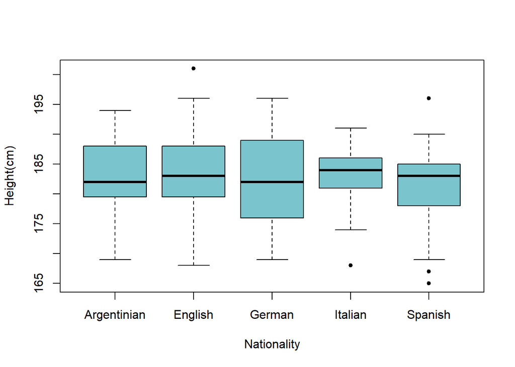

```r
soccer_wrk %>%
  with(
    boxplot(Height ~ Nationality, col = "cadetblue3", pch=20, ylab="Height(cm)")
  )
```

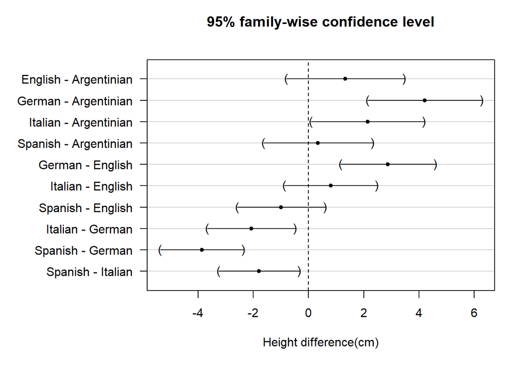

```r
par(mar=c(5,10,4,1)+0.1)
HBW.comp2 %>%plot (xlab="Height difference(cm)")
```